# Spatial Analytics Assignment 3

# Task 1: Load ancient cities and convert to sf object

Use read_csv() to load Hanson2016_Cities_OxREP.csv dataset from the provided URL and assign it to cities object

```r
cities <- as.data.frame(read_csv("http://oxrep.classics.ox.ac.uk/oxrep/docs/Hanson2016/Hanson2016_Cities_OxREP.csv")) #Load the .csv-file as a dataframe and save it as "cities".
```

… then reproject this data to EPSG 3035

```r
# Convert the table into an sf object on the basis of X and Y columns
cities_sf <- st_as_sf(cities, coords = c("Longitude (X)", "Latitude (Y)"))

# Define the projection of Lat/Long coordinates as EPSG 4326
cities_sf4326<- st_set_crs(cities_sf, value = 4326)

# Transform the projection to a 2D projection using EPSG 3035
cities_sf3035<- st_transform(cities_sf4326, crs=3035)

# Verify the projection is 'projected' not 'geographic'
head(cities_sf3035)
```

```
## Simple feature collection with 6 features and 10 fields
## geometry type:  POINT
## dimension:      XY
## bbox:           xmin: 5380930 ymin: 1734580 xmax: 5527223 ymax: 1817990
## CRS:            EPSG:3035
##    Primary Key Ancient Toponym Modern Toponym Province Country
## 1 Hanson2016_1            Abae       Kalapodi   Achaea  Greece
## 2 Hanson2016_2        Acharnae       Acharnes   Achaea  Greece
## 3 Hanson2016_3       Acraephia      Akraifnio   Achaea  Greece
## 4 Hanson2016_4          Aegina         Aigina   Achaea  Greece
## 5 Hanson2016_5          Aegira        Aigeira   Achaea  Greece
## 6 Hanson2016_6          Aegium          Aigio   Achaea  Greece
##   Barrington Atlas Rank Barrington Atlas Reference Start Date End Date
## 1                4 or 5                      55 D3       -600     NULL
## 2                     3                      59 B2       -600     NULL
```

[output cut: 18 more lines]

# Question 1:

What are the measurement units of the cities_sf3035 object?

```r
st_crs(cities_sf3035)$units
```

```
## [1] "m"
```

# Answer 1:

The unit is meters.

# Task 2: Create a buffer around each city and inspect the result

As each city and inscription corresponds to a dot on the map, the best way to grab and review the inscriptions will be by creating a buffer around each city point and then selecting inscriptions on the basis of that.

- Create a buffer around the projected ‘cities’ geometry with ‘st_buffer()’, setting the dist argument to the desired radius of 5000m.
- Plot the resulting buffer with city on top for quick review.

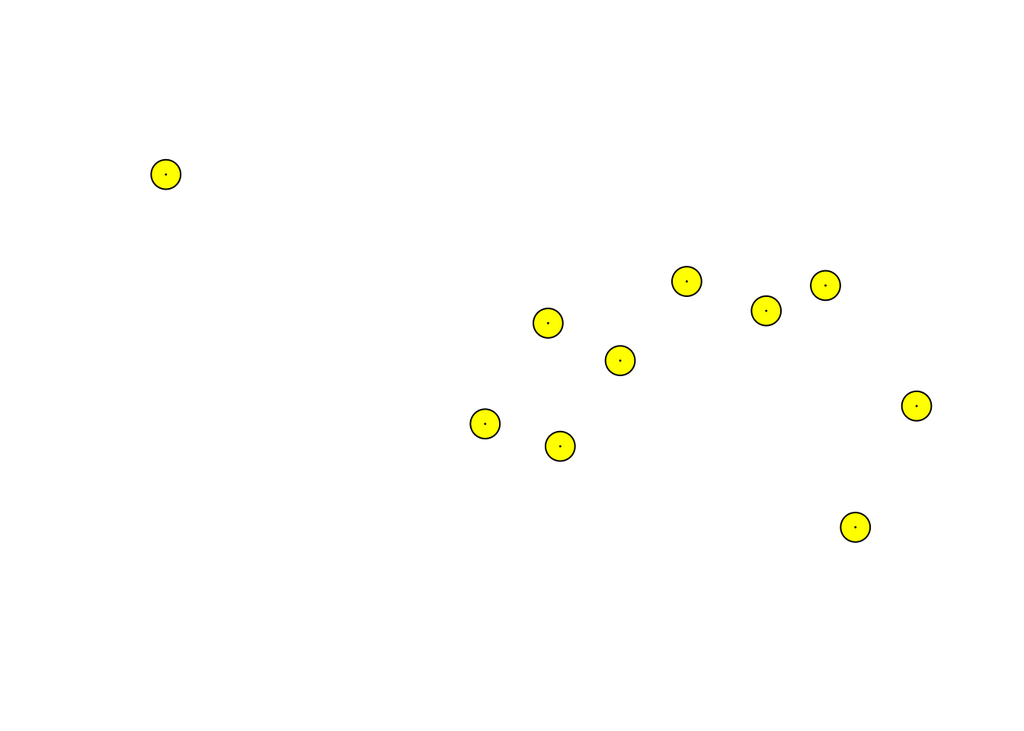

```r
# Make buffer of 5 km. Check the units of your object to correctly assign value to dist
cities_5km<- st_buffer(cities_sf3035,dist = 5000)

# Plot the first 10 buffers and cities to check result
plot(st_geometry(cities_5km)[1:10], col = "yellow")
plot(st_geometry(cities_sf3035)[1:10], pch=20, cex = 0.1, add = TRUE)
```

# Task 3: Verify the city buffers are indeed 5km in radius

Well, a quick review may look ok, but you cannot be sure your buffers work well until you add them to a map with a scale. Verify that your buffers are as big as should be by plotting a sample with tmap and adding a scale of good resolution.

- Grab the first 10 cities and buffers with slice() function
- Load tmap package and plot the 10 cities and buffers with a scale of 0,10,20km. Add names and background for clarity. Do your buffers span 10km across or do they span the universe? (If the latter, recheck your CRS, units, and dist argument)

```r
# Grab the first 10 elements in the sf object and the buffer
ten_buffers <- cities_5km %>% slice(1:10)
ten_cities <- cities_sf3035 %>% slice(1:10)

# Create a quick tmap
library(tmap)
current.mode <- tmap_mode("plot")
```

```
## tmap mode set to plotting
```

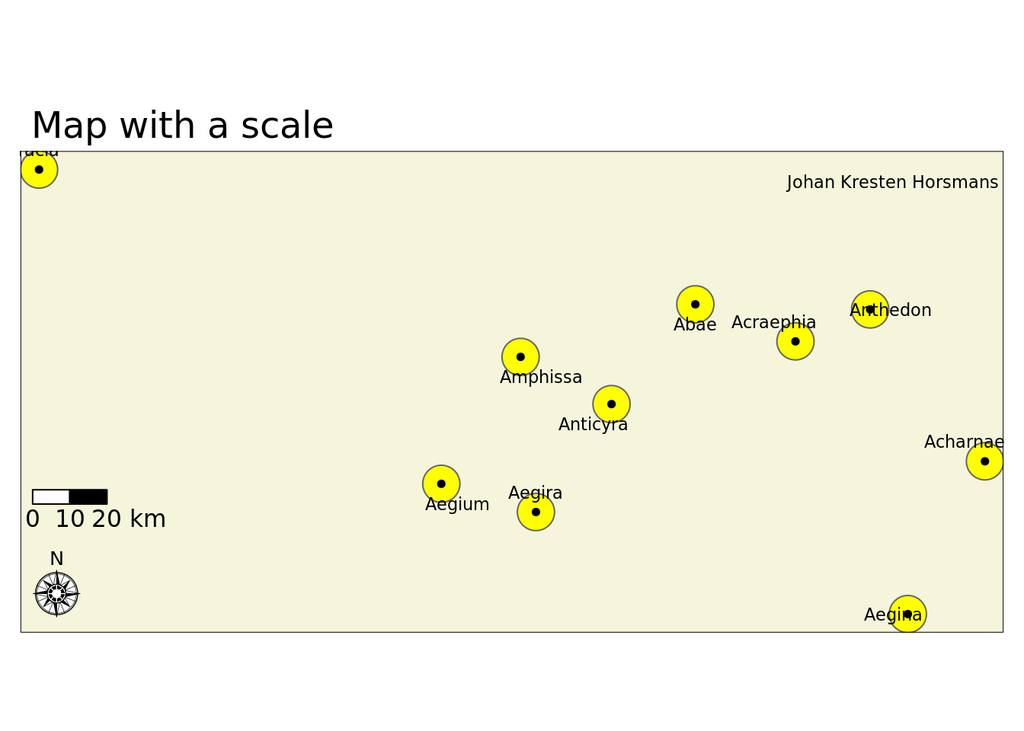

```r
tm_shape(ten_buffers)  +
  tm_polygons(col = "yellow") +
  tm_shape(ten_cities) +
  tm_text("Ancient Toponym", size = 0.7, auto.placement = 5) +
  tm_dots(col = "black",
             size = 0.1) +
  tm_scale_bar(breaks = c(0, 10,20),
               text.size = 10,
               position = c("LEFT", "bottom")) +
  tm_compass(position = c("LEFT", "bottom"),
             type = "rose",
             size = 2) +
  tm_credits(position = c("RIGHT", "top"),
             text = "Johan Kresten Horsmans") +
  tm_layout(main.title = "Map with a scale",
            bg.color = "beige",
            inner.margins = c(0, 0, 0, 0))
```

If all went well, you should see a map, where the diameter of each city buffer corresponds to the 10km notch on the scale

# Task 4: Download ancient inscriptions and wrangle coordinates into shape

Let’s now look at some data that spatially co-occurs with these ancient places. Below is a link to an online dataset from the Epigraphic Database of Heidelberg of ancient inscriptions from one part of the ancient world. These inscriptions combine private and official expressions dedicated for personal reasons (death of a dear person) or public (dedication of a major building, placement of milestone, etc.).

The json dataset is hefty with some 12 thousand inscriptions and 74 variables. Coordinates are nested in a single column and may need wrangling. Do tasks deliberately in small steps after you test on subsets lest you overwhelm your R.

- Download the linked file with download.file() where you can find it.
- The inscriptions dataset is in .json format, which is becoming the dominant format for sharing data online. Use the jsonlite::fromJSON function in the library to load it back into R
- Next, use as_tibble() to convert into rectangular format.
- Check the column names looking for something that holds spatial data. There should be a coordinates column. Look at the column whether it holds meaningful coordinates.
- Separate the two values inside single coordinate column and create a separate longitude and a latitude column, which contain clean decimal numbers. You will need to clean up non-numeric characters en route. Make sure to keep the decimal point. Hint: there are lots of ways of getting clean decimal coordinates into two new columns, so feel free to diverge from the suggested course. Check out the gsub(), grep() and str_extract() functions to implement regular expressions in tidyverse pipeline.

```r
# Libraries
library(tidyverse)
library(jsonlite)
library(tidytext)

# Download the file and save as inscriptions.json (consider commenting out after you first run to avoid repeat downloading)
download.file("https://sciencedata.dk/public/b6b6afdb969d378b70929e86e58ad975/EDH_subset_2021-02-15.json", "data/inscriptions.json")

# Load it into R from wherever you put it, and convert into a tibble
list_json <- jsonlite::fromJSON("data/inscriptions.json")
inscriptions = as_tibble(list_json)

# Check the first couple lines and column names
head(inscriptions)
```

```
## # A tibble: 6 x 74
##   responsible_ind… type_of_inscrip… letter_size not_after literature work_status
##   <chr>            <chr>            <chr>       <chr>     <chr>      <chr>
## 1 Feraudi          epitaph          3.2-2 cm    0130      AE 1983, … provisional
## 2 Feraudi          epitaph          4 cm        0200      AE 1983, … no image
## 3 Feraudi          epitaph          <NA>        0200      AE 1983, … no image
## 4 Feraudi          epitaph          9 cm        -0051     AE 1983, … checked wi…
## 5 Feraudi          epitaph          4-2 cm      0200      AE 1983, … provisional
## 6 Gräf             epitaph          4.2-2.5 cm  0200      AE 1983, … checked wi…
## # … with 68 more variables: height <chr>, diplomatic_text <chr>, people <list>,
## #   depth <chr>, material <chr>, type_of_monument <chr>, province_label <chr>,
## #   width <chr>, transcription <chr>, country <chr>, uri <chr>,
## #   findspot_ancient <chr>, last_update <chr>, modern_region <chr>,
## #   findspot_modern <chr>, language <chr>, id <chr>, edh_geography_uri <chr>,
## #   commentary <chr>, trismegistos_uri <chr>, not_before <chr>,
## #   external_image_uris <list>, fotos <list>, coordinates <list>,
## #   idno_tm <chr>, placenames_refs <list>, text_edition <chr>,
## #   origdate_text <chr>, layout_execution <chr>, layout_execution_text <chr>,
## #   support_objecttype <chr>, support_objecttype_text <chr>,
## #   support_material <chr>, support_material_text <chr>,
## #   support_decoration <chr>, keywords_term <chr>, keywords_term_text <chr>,
## #   type_of_inscription_clean <chr>, type_of_inscription_certainty <chr>,
## #   height_cm <dbl>, width_cm <dbl>, depth_cm <dbl>, material_clean <chr>,
## #   type_of_monument_clean <chr>, type_of_monument_certainty <chr>,
## #   province_label_clean <chr>, province_label_certainty <chr>,
## #   country_clean <chr>, country_certainty <chr>, findspot_ancient_clean <chr>,
## #   findspot_ancient_certainty <chr>, modern_region_clean <chr>,
## #   modern_region_certainty <chr>, findspot_modern_clean <chr>,
## #   findspot_modern_certainty <chr>, findspot_clean <chr>,
## #   findspot_certainty <chr>, origdate_text_clean <chr>,
## #   clean_text_conservative <chr>, clean_text_interpretive_word <chr>,
## #   clean_text_interpretive_sentence <chr>, findspot <chr>, year_of_find <chr>,
## #   present_location <chr>, geography <chr>,
## #   social_economic_legal_history <chr>, religion <chr>, military <chr>
```

```r
colnames(inscriptions)
```

```
##  [1] "responsible_individual"           "type_of_inscription"
##  [3] "letter_size"                      "not_after"
##  [5] "literature"                       "work_status"
##  [7] "height"                           "diplomatic_text"
##  [9] "people"                           "depth"
## [11] "material"                         "type_of_monument"
## [13] "province_label"                   "width"
## [15] "transcription"                    "country"
## [17] "uri"                              "findspot_ancient"
## [19] "last_update"                      "modern_region"
## [21] "findspot_modern"                  "language"
## [23] "id"                               "edh_geography_uri"
## [25] "commentary"                       "trismegistos_uri"
## [27] "not_before"                       "external_image_uris"
## [29] "fotos"                            "coordinates"
```

[output cut: 22 more lines]

```r
# Wrangle the coordinates into a plottable  format
i_sm <- inscriptions %>%
  slice(1:100) %>%
  separate(col = coordinates, into = c("longitude","latitude"), sep = ",") %>%
  mutate(latitude = as.numeric(gsub("[)]", "", latitude)),
         longitude = as.numeric(gsub("[c(]", "", longitude)))
i_sm <- inscriptions %>%
  slice(1:100) %>%
  separate(col = coordinates, into = c("longitude","latitude"), sep = ",") %>% #Split longitude and lattitude into two columns.
  mutate(latitude = as.numeric(gsub("[)]", "", latitude)), #Remove the excess ")" from the latitude-column.
         longitude = as.numeric(gsub("[c(]", "", longitude))) #Remove the excess "c(" from the longitude-column.
library(leaflet) #Load leaflet.
# Check the result of the subset, does the location look reasonable?
leaflet() %>% addTiles() %>% addMarkers(lng=i_sm$longitude,lat=i_sm$latitude)
```

[interactive chart not shown]

# Question 2:

Which part of the world are the inscriptions from?

# Answer 2:

The inscriptions are from Italy.

# Task 5: Convert inscriptions into an sf object

Now that the hard work is done, let’s apply the wrangling to the full dataset and clean up the missing coordinates and outlier values.

- Not all coordinates are complete. Remove the rows with missing latitude or longitude
- Some incorrect points have sneaked in! Eliminate data with longitude smaller than 5 and larger than 20 degrees.
- Make the resulting inscriptions tibble into an sf object using the newly created and cleaned longitude and latitude column in the coords argument. The CRS of the data is 4326.
- Plot your data using st_geometry()

```r
i <- inscriptions %>%
  separate(col = coordinates, into = c("longitude","latitude"), sep = ",") %>%
  mutate(latitude = as.numeric(gsub("[)]", "", latitude)),
         longitude = as.numeric(gsub("[c(]", "", longitude))) %>%
  filter(!is.na(longitude)) %>%
  filter(!is.na(latitude)) %>%
  filter(longitude > 5 && longitude < 20)
```

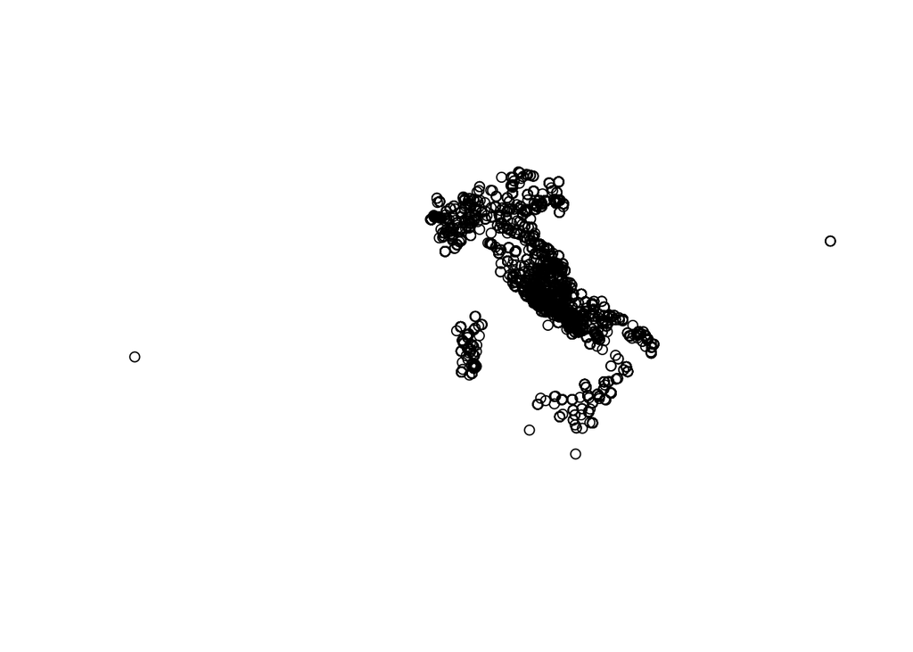

```r
# Create a sf object
insc_sf4326 <- st_as_sf(i, coords = c("longitude", "latitude"), crs = 4326)

# Plot
plot(st_geometry(insc_sf4326))
```

# Task 6: Select inscriptions that fall into the cities’ buffer

Now that you have both the cities and inscriptions in the same CRS, you can pick the inscriptions which fall within 5km radius of the ancient places in order to locate “urban” inscriptions. Use the inverse st_difference to locate “rural” inscriptions.

To reduce the computational intensity of the final intersection, it is a good idea to limit the dissolved city buffer object only to the area within the convex hull of the inscriptions. For the convex hull, you will need to combine the inscriptions into a MULTIPOINT feature using st_union().

- Ensure that the spatial reference system in cities_5km buffer object and inscriptions is consistent.
- Create a convex hull for the inscriptions after combining them into a MULTIPOINT.
- Combine the city buffers into a single multipolygon
- Use st_intersection() to clip the inscriptions that fall within the buffer object and assign to insc_urban object
- Use st_difference flag to select inscriptions outside these buffers and create insc_rural object

```r
# Project the sf object into EPSG3035 so it is consistent with cities and their buffers
insc_sf3035 <- st_transform(cities_5km, crs = 3035)


# Create a convex hull around the inscriptions's points dissolved into a MULTIPOINT
insc_ch <- st_convex_hull(st_union(insc_sf3035))

# Create a buffer from a cluster of cities that fall within the convex hull
cities_it <- st_intersection(insc_ch, cities_5km)

# Dissolve the 399 buffers into a single MULTIPOLYGON buffer feature
c_buff <- st_union(cities_it)

# Calculate the number of inscriptions in urban and rural areas. This may take a couple seconds
insc_urban <- st_intersection(insc_sf3035, c_buff)
insc_rural <- st_difference(insc_sf3035, c_buff)
```

# Question 3:

What is the ratio of urban to rural inscriptions?

```r
#Calculating ratio:
length(insc_urban)/length(insc_rural)
```

```
## [1] 1
```

# Answer 3:

The ratio is 1.